You can find all the data in `../readonly/final_project_data` folder or download it from [Kaggle](https://inclass.kaggle.com/c/competitive-data-science-final-project) if you are solving locally.

**Good luck!**

### I recived help from here https://www.kaggle.com/sarthakbatra/predicting-sales-tutorial

# Import data

```python
# This Python 3 environment comes with many helpful analytics libraries installed
# It is defined by the kaggle/python docker image: https://github.com/kaggle/docker-python
# For example, here's several helpful packages to load in

import numpy as np # linear algebra
import pandas as pd # data processing, CSV file I/O (e.g. pd.read_csv)
%matplotlib inline
import seaborn as sns
import matplotlib.pyplot as plt
from IPython.core.interactiveshell import InteractiveShell
InteractiveShell.ast_node_interactivity = "all"
import gc
from itertools import product
from sklearn.linear_model import LinearRegression
from sklearn.metrics import r2_score
import lightgbm as lgb
import copy
from sklearn.model_selection import KFold, StratifiedKFold
from sklearn.preprocessing import StandardScaler
import pickle
from sklearn.metrics import mean_squared_error
import joblib
```

```python
# Input data files are available in the "../input/" directory.
# For example, running this (by clicking run or pressing Shift+Enter) will list the files in the input directory

import os
print(os.listdir(".."))

items_df = pd.read_csv('items.csv')
shops_df = pd.read_csv('shops.csv')

icats_df = pd.read_csv('item_categories.csv')
train_df = pd.read_csv('sales_train.csv')
smpsb_df = pd.read_csv('sample_submission.csv')
test_df  = pd.read_csv('test.csv')
# Any results you write to the current directory are saved as output.
```

[output not shown]

# Exploratory Data Analysis

## items

|  | item_name | item_id | item_category_id |
| --- | --- | --- | --- |
| 0 | ! ВО ВЛАСТИ НАВАЖДЕНИЯ (ПЛАСТ.) D | 0 | 40 |
| 1 | !ABBYY FineReader 12 Professional Edition Full... | 1 | 76 |
| 2 | ***В ЛУЧАХ СЛАВЫ (UNV) D | 2 | 40 |
| 3 | ***ГОЛУБАЯ ВОЛНА (Univ) D | 3 | 40 |
| 4 | ***КОРОБКА (СТЕКЛО) D | 4 | 40 |

```
item_name           object
item_id              int64
item_category_id     int64
dtype: object
```

|  | item_id | item_category_id |
| --- | --- | --- |
| count | 22170.00000 | 22170.000000 |
| mean | 11084.50000 | 46.290753 |
| std | 6400.07207 | 15.941486 |
| min | 0.00000 | 0.000000 |
| 25% | 5542.25000 | 37.000000 |
| 50% | 11084.50000 | 40.000000 |
| 75% | 16626.75000 | 58.000000 |
| max | 22169.00000 | 83.000000 |

```
array([    0,     1,     2, ..., 22167, 22168, 22169], dtype=int64)
```

```
		Total unique: 22,170
```

```
(<Figure size 720x540 with 1 Axes>,
```

```
isnull total value  0
```

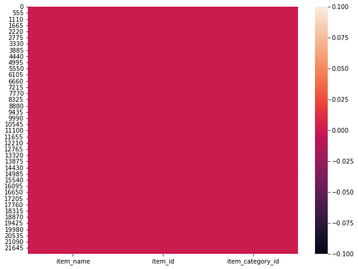

```python
items_df.head(5)
items_df.dtypes
items_df.describe()
items_df.item_id.unique()
print("\t\tTotal unique: {:,}".format(len(items_df.item_id.unique())))
plt.subplots(figsize=(10,7.5))
sns.heatmap(items_df.isnull())
print("isnull total value ", items_df.isnull().sum().values.sum())
#items_df.info
```

## shops

|  | shop_name | shop_id |
| --- | --- | --- |
| 0 | !Якутск Орджоникидзе, 56 фран | 0 |
| 1 | !Якутск ТЦ "Центральный" фран | 1 |
| 2 | Адыгея ТЦ "Мега" | 2 |
| 3 | Балашиха ТРК "Октябрь-Киномир" | 3 |
| 4 | Волжский ТЦ "Волга Молл" | 4 |

```
shop_name    object
shop_id       int64
dtype: object
```

|  | shop_id |
| --- | --- |
| count | 60.000000 |
| mean | 29.500000 |
| std | 17.464249 |
| min | 0.000000 |
| 25% | 14.750000 |
| 50% | 29.500000 |
| 75% | 44.250000 |
| max | 59.000000 |

```
array([ 0,  1,  2,  3,  4,  5,  6,  7,  8,  9, 10, 11, 12, 13, 14, 15, 16,
       17, 18, 19, 20, 21, 22, 23, 24, 25, 26, 27, 28, 29, 30, 31, 32, 33,
       34, 35, 36, 37, 38, 39, 40, 41, 42, 43, 44, 45, 46, 47, 48, 49, 50,
       51, 52, 53, 54, 55, 56, 57, 58, 59], dtype=int64)
```

```
		Total unique: 60
```

```
(<Figure size 720x540 with 1 Axes>,
```

```
isnull total value  0
```

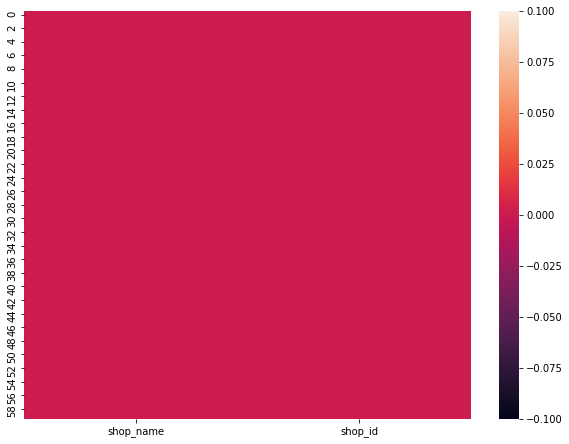

```python
shops_df.head(5)
shops_df.dtypes
shops_df.describe()
shops_df.shop_id.unique()
print("\t\tTotal unique: {:,}".format(len(shops_df.shop_id.unique())))
plt.subplots(figsize=(10,7.5))
sns.heatmap(shops_df.isnull())
print("isnull total value ", shops_df.isnull().sum().values.sum())
```

## item_categories

|  | item_category_name | item_category_id | cats |
| --- | --- | --- | --- |
| 0 | PC - Гарнитуры/Наушники | 0 | PC - Гарнитуры/Наушники |
| 1 | Аксессуары - PS2 | 1 | Access |
| 2 | Аксессуары - PS3 | 2 | Access |
| 3 | Аксессуары - PS4 | 3 | Access |
| 4 | Аксессуары - PSP | 4 | Access |

```
item_category_name    object
item_category_id       int64
cats                  object
dtype: object
```

|  | item_category_id |
| --- | --- |
| count | 84.000000 |
| mean | 41.500000 |
| std | 24.392622 |
| min | 0.000000 |
| 25% | 20.750000 |
| 50% | 41.500000 |
| 75% | 62.250000 |
| max | 83.000000 |

```
array([ 0,  1,  2,  3,  4,  5,  6,  7,  8,  9, 10, 11, 12, 13, 14, 15, 16,
       17, 18, 19, 20, 21, 22, 23, 24, 25, 26, 27, 28, 29, 30, 31, 32, 33,
       34, 35, 36, 37, 38, 39, 40, 41, 42, 43, 44, 45, 46, 47, 48, 49, 50,
       51, 52, 53, 54, 55, 56, 57, 58, 59, 60, 61, 62, 63, 64, 65, 66, 67,
       68, 69, 70, 71, 72, 73, 74, 75, 76, 77, 78, 79, 80, 81, 82, 83],
      dtype=int64)
```

```
		Total unique: 84
```

```
(<Figure size 720x540 with 1 Axes>,
```

```
isnull total value  0
```

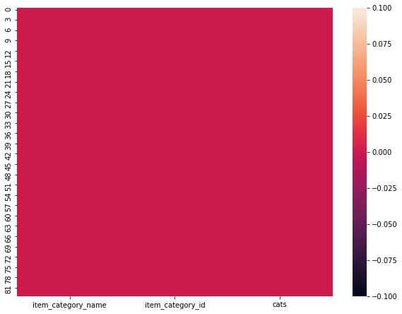

```python
icats_df.head(5)
icats_df.dtypes
icats_df.describe()
icats_df.item_category_id.unique()
print("\t\tTotal unique: {:,}".format(len(icats_df.item_category_id.unique())))
plt.subplots(figsize=(10,7.5))
sns.heatmap(icats_df.isnull())
print("isnull total value ", icats_df.isnull().sum().values.sum())
```

## sales_train

|  | date | date_block_num | shop_id | item_id | item_price | item_cnt_day |
| --- | --- | --- | --- | --- | --- | --- |
| 0 | 02.01.2013 | 0 | 59 | 22154 | 999.00 | 1.0 |
| 1 | 03.01.2013 | 0 | 25 | 2552 | 899.00 | 1.0 |
| 2 | 05.01.2013 | 0 | 25 | 2552 | 899.00 | -1.0 |
| 3 | 06.01.2013 | 0 | 25 | 2554 | 1709.05 | 1.0 |
| 4 | 15.01.2013 | 0 | 25 | 2555 | 1099.00 | 1.0 |

```
date               object
date_block_num      int64
shop_id             int64
item_id             int64
item_price        float64
item_cnt_day      float64
dtype: object
```

|  | date_block_num | shop_id | item_id | item_price | item_cnt_day |
| --- | --- | --- | --- | --- | --- |
| count | 2.935849e+06 | 2.935849e+06 | 2.935849e+06 | 2.935849e+06 | 2.935849e+06 |
| mean | 1.456991e+01 | 3.300173e+01 | 1.019723e+04 | 8.908532e+02 | 1.242641e+00 |
| std | 9.422988e+00 | 1.622697e+01 | 6.324297e+03 | 1.729800e+03 | 2.618834e+00 |
| min | 0.000000e+00 | 0.000000e+00 | 0.000000e+00 | -1.000000e+00 | -2.200000e+01 |
| 25% | 7.000000e+00 | 2.200000e+01 | 4.476000e+03 | 2.490000e+02 | 1.000000e+00 |
| 50% | 1.400000e+01 | 3.100000e+01 | 9.343000e+03 | 3.990000e+02 | 1.000000e+00 |
| 75% | 2.300000e+01 | 4.700000e+01 | 1.568400e+04 | 9.990000e+02 | 1.000000e+00 |
| max | 3.300000e+01 | 5.900000e+01 | 2.216900e+04 | 3.079800e+05 | 2.169000e+03 |

```
array([22154,  2552,  2554, ...,  7610,  7635,  7640], dtype=int64)
```

```
		Total unique: 21,807
```

```
(<Figure size 720x540 with 1 Axes>,
```

```
isnull total value  0
```

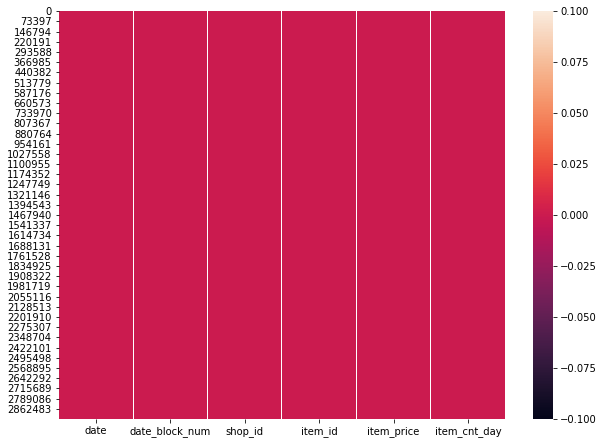

```python
train_df.head(5)
train_df.dtypes
train_df.describe()
train_df.item_id.unique()
print("\t\tTotal unique: {:,}".format(len(train_df.item_id.unique())))
plt.subplots(figsize=(10,7.5))
sns.heatmap(train_df.isnull())
print("isnull total value ", train_df.isnull().sum().values.sum())
```

## sample_submission

|  | ID | item_cnt_month |
| --- | --- | --- |
| 0 | 0 | 0.5 |
| 1 | 1 | 0.5 |
| 2 | 2 | 0.5 |
| 3 | 3 | 0.5 |
| 4 | 4 | 0.5 |

```
ID                  int64
item_cnt_month    float64
dtype: object
```

|  | ID | item_cnt_month |
| --- | --- | --- |
| count | 214200.000000 | 214200.0 |
| mean | 107099.500000 | 0.5 |
| std | 61834.358168 | 0.0 |
| min | 0.000000 | 0.5 |
| 25% | 53549.750000 | 0.5 |
| 50% | 107099.500000 | 0.5 |
| 75% | 160649.250000 | 0.5 |
| max | 214199.000000 | 0.5 |

```
array([     0,      1,      2, ..., 214197, 214198, 214199], dtype=int64)
```

```
		Total unique: 214,200
```

```
(<Figure size 720x540 with 1 Axes>,
```

```
isnull total value  0
```

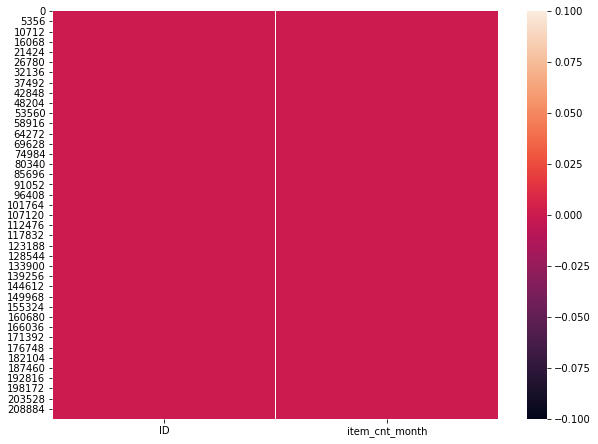

```python
smpsb_df.head(5)
smpsb_df.dtypes
smpsb_df.describe()
smpsb_df.ID.unique()
print("\t\tTotal unique: {:,}".format(len(smpsb_df.ID.unique())))
plt.subplots(figsize=(10,7.5))
sns.heatmap(smpsb_df.isnull())
print("isnull total value ", smpsb_df.isnull().sum().values.sum())
```

## test

|  | ID | shop_id | item_id |
| --- | --- | --- | --- |
| 0 | 0 | 5 | 5037 |
| 1 | 1 | 5 | 5320 |
| 2 | 2 | 5 | 5233 |
| 3 | 3 | 5 | 5232 |
| 4 | 4 | 5 | 5268 |

```
ID         int64
shop_id    int64
item_id    int64
dtype: object
```

|  | ID | shop_id | item_id |
| --- | --- | --- | --- |
| count | 214200.000000 | 214200.000000 | 214200.000000 |
| mean | 107099.500000 | 31.642857 | 11019.398627 |
| std | 61834.358168 | 17.561933 | 6252.644590 |
| min | 0.000000 | 2.000000 | 30.000000 |
| 25% | 53549.750000 | 16.000000 | 5381.500000 |
| 50% | 107099.500000 | 34.500000 | 11203.000000 |
| 75% | 160649.250000 | 47.000000 | 16071.500000 |
| max | 214199.000000 | 59.000000 | 22167.000000 |

```
array([     0,      1,      2, ..., 214197, 214198, 214199], dtype=int64)
```

```
		Total unique: 214,200
```

```
(<Figure size 720x540 with 1 Axes>,
```

```
isnull total value  0
```

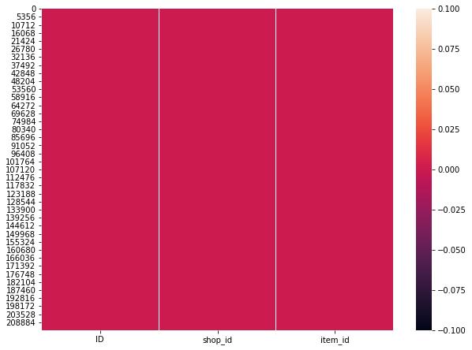

```python
test_df.head(5)
test_df.dtypes
test_df.describe()
test_df.ID.unique()
print("\t\tTotal unique: {:,}".format(len(test_df.ID.unique())))
plt.subplots(figsize=(10,7.5))
sns.heatmap(test_df.isnull())
print("isnull total value ", test_df.isnull().sum().values.sum())
```

## train correlation

```python
train_df.corr()
```

|  | date_block_num | shop_id | item_id | item_price | item_cnt_day |
| --- | --- | --- | --- | --- | --- |
| date_block_num | 1.000000 | 0.019273 | 0.009356 | 0.095010 | 0.009402 |
| shop_id | 0.019273 | 1.000000 | 0.029396 | -0.024034 | -0.005230 |
| item_id | 0.009356 | 0.029396 | 1.000000 | -0.134104 | 0.016650 |
| item_price | 0.095010 | -0.024034 | -0.134104 | 1.000000 | 0.011197 |
| item_cnt_day | 0.009402 | -0.005230 | 0.016650 | 0.011197 | 1.000000 |

## train date_block_num

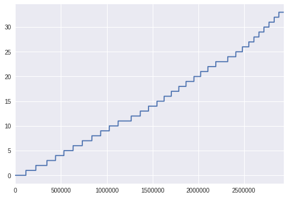

```python
train_df.date_block_num.plot()
```

## train item_price

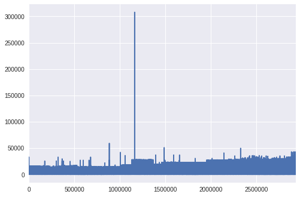

```python
train_df.item_price.plot()
```

```python
train_df[train_df.item_price > 60000]
items_df[items_df.item_id == 6066]
icats_df[icats_df.item_category_id == 75]
```

|  | date | date_block_num | shop_id | item_id | item_price | item_cnt_day |
| --- | --- | --- | --- | --- | --- | --- |
| 1163158 | 13.12.2013 | 11 | 12 | 6066 | 307980.0 | 1.0 |

|  | item_name | item_id | item_category_id |
| --- | --- | --- | --- |
| 6066 | Radmin 3 - 522 лиц. | 6066 | 75 |

|  | item_category_name | item_category_id |
| --- | --- | --- |
| 75 | Программы - Для дома и офиса | 75 |

## train item_cnt_day

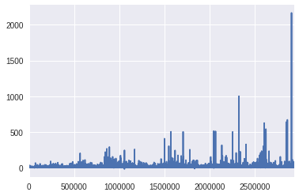

```python
train_df.item_cnt_day.plot()
```

### there is a quantity of sales over 1000 Gifts - Bags, Albums, Mats and Delivery to the collection point (Boxberry)

```python
train_df[train_df.item_cnt_day > 800]
items_df[(items_df.item_id == 20949) | (items_df.item_id == 11373)]
icats_df[(icats_df.item_category_id == 71) | (icats_df.item_category_id == 9)]
```

|  | date | date_block_num | shop_id | item_id | item_price | item_cnt_day |
| --- | --- | --- | --- | --- | --- | --- |
| 2326930 | 15.01.2015 | 24 | 12 | 20949 | 4.000000 | 1000.0 |
| 2909818 | 28.10.2015 | 33 | 12 | 11373 | 0.908714 | 2169.0 |

|  | item_name | item_id | item_category_id |
| --- | --- | --- | --- |
| 11373 | Доставка до пункта выдачи (Boxberry) | 11373 | 9 |
| 20949 | Фирменный пакет майка 1С Интерес белый (34*42)... | 20949 | 71 |

|  | item_category_name | item_category_id | cats |
| --- | --- | --- | --- |
| 9 | Доставка товара | 9 | Доставка товара |
| 71 | Подарки - Сумки, Альбомы, Коврики д/мыши | 71 | Gifts |

### Clean or exclude information from data outliers

```python
train_df2 = train_df[train_df.item_price < 100000]
train_df2 = train_df[train_df.item_cnt_day < 900]
```

```python
# drop duplicates
subset = ['date','date_block_num','shop_id','item_id','item_cnt_day']
print(train_df2.duplicated(subset=subset).value_counts())
train_df2.drop_duplicates(subset=subset, inplace=True)
```

```
False    2935823
True          24
dtype: int64
```

```python
train_df2.head()
```

|  | date | date_block_num | shop_id | item_id | item_price | item_cnt_day |
| --- | --- | --- | --- | --- | --- | --- |
| 0 | 02.01.2013 | 0 | 59 | 22154 | 999.00 | 1.0 |
| 1 | 03.01.2013 | 0 | 25 | 2552 | 899.00 | 1.0 |
| 2 | 05.01.2013 | 0 | 25 | 2552 | 899.00 | -1.0 |
| 3 | 06.01.2013 | 0 | 25 | 2554 | 1709.05 | 1.0 |
| 4 | 15.01.2013 | 0 | 25 | 2555 | 1099.00 | 1.0 |

# Test Set Distribution

### Now, let's do the distribution analysis for the test set and see if we can spot any differences

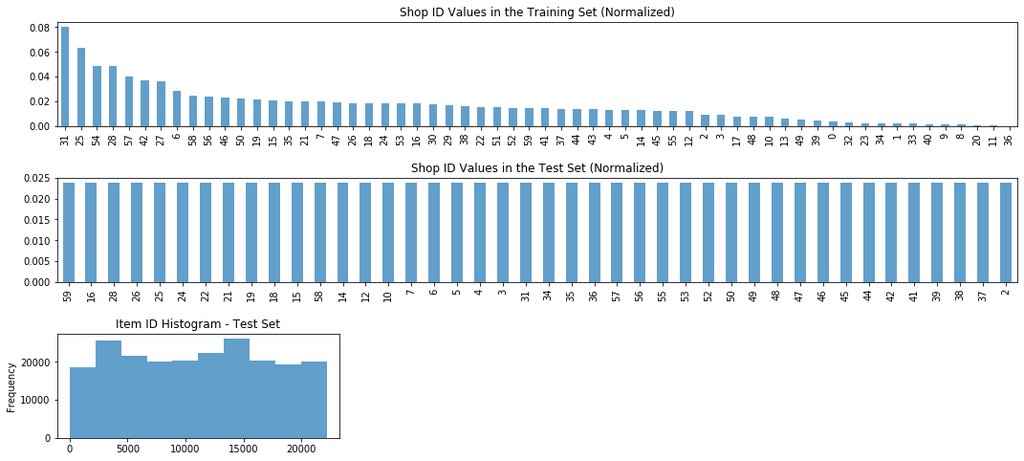

```python
fig = plt.figure(figsize=(18,8))
plt.subplots_adjust(hspace=.5)

plt.subplot2grid((3,3), (0,0), colspan = 3)
train_df['shop_id'].value_counts(normalize=True).plot(kind='bar', alpha=0.7)
plt.title('Shop ID Values in the Training Set (Normalized)')

plt.subplot2grid((3,3), (1,0), colspan = 3)
test_df['shop_id'].value_counts(normalize=True).plot(kind='bar', alpha=0.7)
plt.title('Shop ID Values in the Test Set (Normalized)')

plt.subplot2grid((3,3), (2,0))
test_df['item_id'].plot(kind='hist', alpha=0.7)
plt.title('Item ID Histogram - Test Set')

plt.show()
```

It seems there might be some values of shop_id and item_id completely missing in the test set. Let's have a closer look and put some numbers or percentages to these missing values.

# Shops Analysis

```python
shops_train = train_df['shop_id'].nunique()
shops_test = test_df['shop_id'].nunique()
print('Shops in Training Set: ', shops_train)
print('Shops in Test Set: ', shops_test)
```

```
Shops in Training Set:  60
Shops in Test Set:  42
```

```python
if(set(test_df['shop_id'].unique()).issubset(set(train_df['shop_id'].unique()))):
    print ("Yes, list of shops test is subset of shops train.")
else :
     print ("No, list of shops test is not subset of shops train.")
```

```
Yes, list of shops test is subset of shops train.
```

# Items Analysis

```python
items_train = train_df['item_id'].nunique()
items_test = test_df['item_id'].nunique()
print('Items in Training Set: ', items_train)
print('Items in Test Set: ', items_test)
```

```
Items in Training Set:  21807
Items in Test Set:  5100
```

```python
if(set(test_df['item_id'].unique()).issubset(set(train_df['item_id'].unique()))):
    print ("Yes, list of items test is subset of items train.")
else :
     print ("No, list of items test is not subset of items train.")
```

```
No, list of items test is not subset of items train.
```

```python
len(set(test_df['item_id'].unique()).difference(train_df['item_id'].unique()))
```

```
363
```

```python
train_df.count()
train_df2.count()
test_df.count()
```

```
date              2935849
date_block_num    2935849
shop_id           2935849
item_id           2935849
item_price        2935849
item_cnt_day      2935849
dtype: int64
```

```
date              2935823
date_block_num    2935823
shop_id           2935823
item_id           2935823
item_price        2935823
item_cnt_day      2935823
dtype: int64
```

```
ID         214200
shop_id    214200
item_id    214200
dtype: int64
```

# Encoding Categorical

```python
cities = shops_df['shop_name'].str.split(' ').map(lambda row: row[0])
shops_df['city'] = shops_df['shop_name'].str.split(' ').map(lambda row: row[0])
shops_df.loc[shops_df.city == '!Якутск', 'city'] = 'Якутск'
```

```python
from sklearn import preprocessing
le = preprocessing.LabelEncoder()
le.fit_transform(shops_df['city'])
```

```
array([29, 29,  0,  1,  2,  3,  4,  4,  4,  5,  6,  6,  7,  8,  8,  9, 10,
       11, 11, 12, 13, 13, 13, 13, 13, 13, 13, 13, 13, 13, 13, 13, 13, 14,
       15, 15, 16, 16, 17, 18, 18, 18, 19, 19, 20, 20, 21, 22, 23, 24, 24,
       24, 25, 25, 26, 27, 28, 29, 29, 30])
```

```python
shops_df['city_label'] = le.fit_transform(shops_df['city'])
shops_df.drop(['shop_name', 'city'], axis = 1, inplace = True)
shops_df.head()
```

|  | shop_id | city_label |
| --- | --- | --- |
| 0 | 0 | 29 |
| 1 | 1 | 29 |
| 2 | 2 | 0 |
| 3 | 3 | 1 |
| 4 | 4 | 2 |

# Extract text features

## Grouping Common Categories Te and Extracting Sub-Categories

## Upon examing the above matrices, one can spot a trend of main and sub-categories. These are in the dataframe, before the hyphen. Let's extract them!

```python
le = preprocessing.LabelEncoder()

main_categories = icats_df['item_category_name'].str.split('-')
icats_df['main_category_id'] = main_categories.map(lambda row: row[0].strip())
icats_df['main_category_id'] = le.fit_transform(icats_df['main_category_id'])

# Some items don't have sub-categories. For those, we will use the main category as a sub-category
icats_df['sub_category_id'] = main_categories.map(lambda row: row[1].strip() if len(row) > 1 else row[0].strip())
icats_df['sub_category_id'] = le.fit_transform(icats_df['sub_category_id'])
icats_df.head()
```

|  | item_category_name | item_category_id | main_category_id | sub_category_id |
| --- | --- | --- | --- | --- |
| 0 | PC - Гарнитуры/Наушники | 0 | 0 | 29 |
| 1 | Аксессуары - PS2 | 1 | 1 | 9 |
| 2 | Аксессуары - PS3 | 2 | 1 | 10 |
| 3 | Аксессуары - PS4 | 3 | 1 | 11 |
| 4 | Аксессуары - PSP | 4 | 1 | 13 |

# Utility functions

```python
def downcast_dtypes(df):
    '''
        Changes column types in the dataframe:

                `float64` type to `float32`
                `int64`   type to `int32`
    '''

    # Select columns to downcast
    float_cols = [c for c in df if df[c].dtype == "float64"]
    int_cols =   [c for c in df if df[c].dtype == "int64"]

    # Downcast
    df[float_cols] = df[float_cols].astype(np.float32)
    df[int_cols]   = df[int_cols].astype(np.int32)

    return df
```

```python
def reduce_mem_usage(df, verbose=True):
    numerics = ['int16', 'int32', 'int64', 'float16', 'float32', 'float64']
    start_mem = df.memory_usage().sum() / 1024**2
    for col in df.columns:
        col_type = df[col].dtypes
        if col_type in numerics:
            c_min = df[col].min()
            c_max = df[col].max()
            if str(col_type)[:3] == 'int':
                if c_min > np.iinfo(np.int8).min and c_max < np.iinfo(np.int8).max:
                    df[col] = df[col].astype(np.int8)
                elif c_min > np.iinfo(np.int16).min and c_max < np.iinfo(np.int16).max:
                    df[col] = df[col].astype(np.int16)
                elif c_min > np.iinfo(np.int32).min and c_max < np.iinfo(np.int32).max:
                    df[col] = df[col].astype(np.int32)
                elif c_min > np.iinfo(np.int64).min and c_max < np.iinfo(np.int64).max:
                    df[col] = df[col].astype(np.int64)
            else:
                if c_min > np.finfo(np.float16).min and c_max < np.finfo(np.float16).max:
                    df[col] = df[col].astype(np.float16)
                elif c_min > np.finfo(np.float32).min and c_max < np.finfo(np.float32).max:
                    df[col] = df[col].astype(np.float32)
                else:
                    df[col] = df[col].astype(np.float64)
    end_mem = df.memory_usage().sum() / 1024**2
    if verbose: print('Mem. usage decreased to {:5.2f} Mb ({:.1f}% reduction)'.format(end_mem, 100 * (start_mem - end_mem) / start_mem))
    return df
```

# Aggregate data

### Since the competition task is to make a monthly prediction, we need to aggregate the data to montly level before doing any encodings. The following code-cell serves just that purpose.

```python
# Create "grid" with columns
index_cols = ['shop_id', 'item_id', 'date_block_num']

# For every month we create a grid from all shops/items combinations from that month
grid = []
for block_num in train_df2['date_block_num'].unique():
    cur_shops = train_df2.loc[train_df2['date_block_num'] == block_num, 'shop_id'].unique()
    cur_items = train_df2.loc[train_df2['date_block_num'] == block_num, 'item_id'].unique()
    grid.append(np.array(list(product(*[cur_shops, cur_items, [block_num]])),dtype='int32'))

# Turn the grid into a dataframe
grid = pd.DataFrame(np.vstack(grid), columns = index_cols,dtype=np.int32)

# Groupby data to get shop-item-month aggregates
gb = train_df2.groupby(index_cols)['item_cnt_day'].sum().rename('item_cnt_month').reset_index()

# Join it to the grid
all_data = pd.merge(grid, gb, how='left', on=index_cols).fillna(0)

all_data['item_cnt_month'] = np.clip(all_data['item_cnt_month'], 0, 20)

all_data.sort_values(['date_block_num','shop_id','item_id'], inplace = True)
# Downcast dtypes from 64 to 32 bit to save memory
all_data = downcast_dtypes(all_data)
del grid, gb
gc.collect();
```

```python
all_data.head(5)
```

|  | shop_id | item_id | date_block_num | item_cnt_month |
| --- | --- | --- | --- | --- |
| 139255 | 0 | 19 | 0 | 0.0 |
| 141495 | 0 | 27 | 0 | 0.0 |
| 144968 | 0 | 28 | 0 | 0.0 |
| 142661 | 0 | 29 | 0 | 0.0 |
| 138947 | 0 | 32 | 0 | 6.0 |

# Mean encodings - Expanding mean scheme

```python
cumsum = all_data.groupby('item_id')['item_cnt_month'].cumsum() - all_data['item_cnt_month']
cumcnt = all_data.groupby('item_id').cumcount()

all_data['item_id_mean_target'] = cumsum/cumcnt

all_data['item_id_mean_target'].fillna(0.3343, inplace=True)
encoded_feature = all_data['item_id_mean_target'].values

corr = np.corrcoef(all_data['item_cnt_month'].values, encoded_feature)[0][1]
print(corr)
```

```
0.5605566415870579
```

# Appending Test Set to Training Set

### First, let's insert the date_block_num feature for the test set! Using insert method of pandas to place this new column at a specific index. This will allow us to concatenate the test set easily to the training set before we generate lag features

```python
test_df.insert(loc=3, column='date_block_num', value=34)
test_df['item_cnt_month'] = 0
test_df.head()
```

|  | ID | shop_id | item_id | date_block_num | item_cnt_month |
| --- | --- | --- | --- | --- | --- |
| 0 | 0 | 5 | 5037 | 34 | 0 |
| 1 | 1 | 5 | 5320 | 34 | 0 |
| 2 | 2 | 5 | 5233 | 34 | 0 |
| 3 | 3 | 5 | 5232 | 34 | 0 |
| 4 | 4 | 5 | 5268 | 34 | 0 |

```python
all_data = all_data.append(test_df.drop('ID', axis = 1))
```

```python
all_data = pd.merge(all_data, shops_df, on=['shop_id'], how='left')
all_data = pd.merge(all_data, items_df.drop('item_name', axis = 1), on=['item_id'], how='left')
all_data = pd.merge(all_data, icats_df.drop('item_category_name', axis = 1), on=['item_category_id'], how='left')
all_data.head()
```

|  | shop_id | item_id | date_block_num | item_cnt_month | item_id_mean_target | city_label | item_category_id | main_category_id | sub_category_id |
| --- | --- | --- | --- | --- | --- | --- | --- | --- | --- |
| 0 | 0 | 19 | 0 | 0.0 | 0.3343 | 29 | 40 | 11 | 4 |
| 1 | 0 | 27 | 0 | 0.0 | 0.3343 | 29 | 19 | 5 | 10 |
| 2 | 0 | 28 | 0 | 0.0 | 0.3343 | 29 | 30 | 8 | 55 |
| 3 | 0 | 29 | 0 | 0.0 | 0.3343 | 29 | 23 | 5 | 16 |
| 4 | 0 | 32 | 0 | 6.0 | 0.3343 | 29 | 40 | 11 | 4 |

# Generating Lag Features.

### After creating a grid, we can calculate some features. We will use lags from [1, 2, 3, 4, 5, 6, 12] months ago.

```python
from tqdm import tqdm_notebook
```

```python
import gc
gc.collect()
all_data = downcast_dtypes(all_data)
```

```
56
```

```python
# List of columns that we will use to create lags
cols_to_rename = list(all_data.columns.difference(index_cols))

shift_range = [1, 2, 3, 4, 5, 6, 12]
for month_shift in tqdm_notebook(shift_range):
    train_shift = all_data[index_cols + cols_to_rename].copy()

    train_shift['date_block_num'] = train_shift['date_block_num'] + month_shift

    foo = lambda x: '{}_lag_{}'.format(x, month_shift) if x in cols_to_rename else x
    train_shift = train_shift.rename(columns=foo)

    all_data = pd.merge(all_data, train_shift, on=index_cols, how='left').fillna(0)

del train_shift
```

### save and load data

```python
#all_data.to_csv('all_data2.csv', index=False)
#all_data = pd.read_csv('all_data.csv')
#shift_range = [1, 2, 3, 4, 5, 6, 12]
#index_cols = ['shop_id', 'item_id', 'date_block_num']
#items_df = pd.read_csv('items.csv')
```

# Training/split

## Validation scheme

```python
# Don't use old data from year 2013
all_data = all_data[all_data['date_block_num'] >= 12]

# List of all lagged features
fit_cols = [col for col in all_data.columns if col[-1] in [str(item) for item in shift_range]]
# We will drop these at fitting stage
to_drop_cols = list(set(list(all_data.columns)) - (set(fit_cols)|set(index_cols))) + ['date_block_num']

# Category for each item
item_category_mapping = items_df[['item_id','item_category_id']].drop_duplicates()

all_data = pd.merge(all_data, item_category_mapping, how='left', on='item_id')
all_data = downcast_dtypes(all_data)
gc.collect();
```

### check

```python
# Save `date_block_num`, as we can't use them as features, but will need them to split the dataset into parts
dates = all_data['date_block_num']

last_block = dates.max()
print('Test `date_block_num` is %d' % last_block)
```

```
Test `date_block_num` is 34
```

```python
all_data.dtypes
```

```
shop_id                      int32
item_id                      int32
date_block_num               int32
item_cnt_month             float32
city_label                   int32
item_category_id_x           int32
main_category_id             int32
sub_category_id              int32
city_label_lag_1           float32
item_category_id_lag_1     float32
item_cnt_month_lag_1       float32
main_category_id_lag_1     float32
sub_category_id_lag_1      float32
city_label_lag_2           float32
item_category_id_lag_2     float32
item_cnt_month_lag_2       float32
main_category_id_lag_2     float32
sub_category_id_lag_2      float32
city_label_lag_3           float32
item_category_id_lag_3     float32
item_cnt_month_lag_3       float32
main_category_id_lag_3     float32
sub_category_id_lag_3      float32
city_label_lag_4           float32
item_category_id_lag_4     float32
item_cnt_month_lag_4       float32
main_category_id_lag_4     float32
sub_category_id_lag_4      float32
city_label_lag_5           float32
item_category_id_lag_5     float32
item_cnt_month_lag_5       float32
main_category_id_lag_5     float32
sub_category_id_lag_5      float32
city_label_lag_6           float32
item_category_id_lag_6     float32
item_cnt_month_lag_6       float32
main_category_id_lag_6     float32
sub_category_id_lag_6      float32
city_label_lag_12          float32
item_category_id_lag_12    float32
item_cnt_month_lag_12      float32
main_category_id_lag_12    float32
sub_category_id_lag_12     float32
item_category_id_y           int32
dtype: object
```

```python
X_train = all_data[all_data.date_block_num < 33].drop(['item_cnt_month'], axis=1).values
Y_train = all_data[all_data.date_block_num < 33]['item_cnt_month'].values

X_valid = all_data[all_data.date_block_num == 33].drop(['item_cnt_month'], axis=1).values
Y_valid = all_data[all_data.date_block_num == 33]['item_cnt_month'].values

X_test =  all_data[all_data['date_block_num']==34].drop(['item_cnt_month'], axis=1)
```

# First level models

## Linear Regression Train

```python
scaler = StandardScaler().fit(X_train)
X_train_std = scaler.transform(X_train)
X_valid_std = scaler.transform(X_valid)
```

```python
del scaler
```

```python
%%time
model_linreg = LinearRegression(fit_intercept=True)
model_linreg.fit(X_train_std, Y_train)
#mean_squared_error
print(np.sqrt(mean_squared_error(Y_valid, model_linreg.predict(X_valid_std))))
```

```
0.9700146086308788
Wall time: 2min 15s
Parser   : 566 ms
```

### Model file

```python
pkl_filename = "model2_linreg.pkl"
joblib.dump(model_linreg, pkl_filename)
```

```
['model2_linreg.pkl']
```

## LightGBM Regressor Train

```python
%%time
lgb_train = lgb.Dataset(X_train, Y_train)
lgb_valid = lgb.Dataset(X_valid, Y_valid)

params = {
    'boosting_type': 'dart',
    'metric': 'l2_root', # RMSE
    'verbose': 1,
    'seed': 0,
    'max_depth': 8,
    'learning_rate': 0.1,
    'reg_lambda': 2.0,
    'reg_alpha': 2.0,
    'subsample': 0.7,
    'num_leaves': 20,
    'feature_fraction': 0.8,
    'drop_rate': 0.2
}

model_lgbm = lgb.train(params, lgb_train, num_boost_round=1000, valid_sets=lgb_valid,
                       early_stopping_rounds=200,
                       verbose_eval=50)
```

```
[50]	valid_0's rmse: 0.977499
[100]	valid_0's rmse: 0.947943
[150]	valid_0's rmse: 0.941863
[200]	valid_0's rmse: 0.938943
[250]	valid_0's rmse: 0.938561
[300]	valid_0's rmse: 0.936389
[350]	valid_0's rmse: 0.934395
[400]	valid_0's rmse: 0.93382
[450]	valid_0's rmse: 0.932522
[500]	valid_0's rmse: 0.930821
[550]	valid_0's rmse: 0.931321
[600]	valid_0's rmse: 0.931185
[650]	valid_0's rmse: 0.931409
[700]	valid_0's rmse: 0.932535
[750]	valid_0's rmse: 0.932626
[800]	valid_0's rmse: 0.931257
[850]	valid_0's rmse: 0.930937
[900]	valid_0's rmse: 0.930974
[950]	valid_0's rmse: 0.930792
[1000]	valid_0's rmse: 0.933244
Wall time: 58min 53s
```

```python
#mean_squared_error
print(np.sqrt(mean_squared_error(Y_valid, model_lgbm.predict(X_valid))))
```

```
0.9332444694510821
```

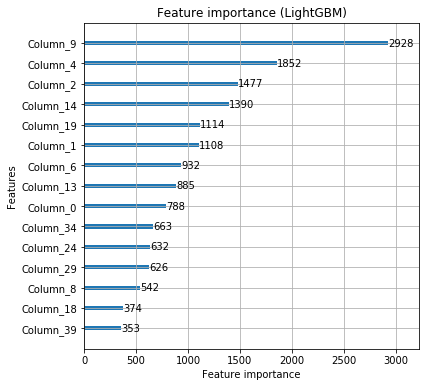

```python
lgb.plot_importance(model_lgbm, max_num_features=15, figsize=(6,6), title='Feature importance (LightGBM)')
plt.show()
```

### Model file

```python
pkl_filename = "model1_lgbm.pkl"
joblib.dump(model_lgbm, pkl_filename)
```

```
['model1_lgbm.pkl']
```

# Ensembling and test predictions

Load model file

```python
#model_lgbm = joblib.load("model1_lgbm.pkl")
#model_linreg = joblib.load("model2_linreg.pkl")
#model_xg = joblib.load("modelxg.pkl")
```

```python
Y_valid_lgbm = model_lgbm.predict(X_valid)
Y_valid_lreg = model_linreg.predict(X_valid_std)
X_valid_level2 = np.c_[Y_valid_lgbm, Y_valid_lreg]
X_valid_level2[:10,:]
```

```
array([[ 0.0298434 ,  0.0064108 ],
       [ 0.03553938, -0.01698188],
       [ 0.19833553,  0.20992585],
       [ 0.26749391,  0.55760308],
       [-0.02245894,  0.05893823],
       [ 0.01396433,  0.07531091],
       [ 0.02620255,  0.05694123],
       [ 0.02620255,  0.05694314],
       [ 0.02620255,  0.05694314],
       [ 0.02620255,  0.05694505]])
```

### Down cast type just in case

```python
all_data = downcast_dtypes(all_data)
```

```python
X_train2 = all_data[all_data['date_block_num']<33].drop(['item_cnt_month'], axis=1)
Y_train2 = all_data[all_data['date_block_num']<33]['item_cnt_month']
X_valid2 = all_data[all_data['date_block_num']==33].drop(['item_cnt_month'], axis=1)
Y_valid2 = all_data[all_data['date_block_num']==33]['item_cnt_month']
```

### Reduce memory usage because sometimes i get error

```python
X_train2 = reduce_mem_usage(X_train2)
X_valid2 = reduce_mem_usage(X_valid2)
```

```
Mem. usage decreased to 513.33 Mb (51.7% reduction)
Mem. usage decreased to 19.76 Mb (51.7% reduction)
```

```python
dates = all_data['date_block_num']
last_block = dates.max()
print('Test `date_block_num` is %d' % last_block)
dates_train = dates[dates < last_block]
dates_test  = dates[dates == last_block]
```

```
Test `date_block_num` is 34
```

### Periods months

```python
periods = np.arange(26, 33, 1)
periods
```

```
array([26, 27, 28, 29, 30, 31, 32])
```

```python
dates_train_level2 = dates_train[dates_train.isin(periods)]
Y_train_level2 = Y_train2[dates_train.isin(periods)]
X_train_level2 = np.zeros([Y_train_level2.shape[0], 2])
```

### check

```python
Y_train2[dates_train.isin(periods)].shape == dates_train_level2.shape
```

```
True
```

### Ensembling

```python
%%time
# Now fill `X_train_level2` with metafeatures
params = {
    'boosting_type': 'dart',
    'metric': 'l2_root', # RMSE
    'verbose': 1,
    'seed': 0,
    'max_depth': 8,
    'learning_rate': 0.1,
    'reg_lambda': 2.0,
    'reg_alpha': 2.0,
    'subsample': 0.7,
    'num_leaves': 20,
    'feature_fraction': 0.8,
    'drop_rate': 0.2
}

for cur_block_num in periods:

    print('cur_block_num:', cur_block_num)

    # 1. Split `X_train` into parts
    x = all_data[all_data['date_block_num']<cur_block_num].drop(['item_cnt_month'], axis=1)
    y = all_data[all_data['date_block_num']<cur_block_num]['item_cnt_month'].values
    x_test =  all_data[all_data['date_block_num']==cur_block_num].drop(['item_cnt_month'], axis=1)
    y_test =  all_data[all_data['date_block_num']==cur_block_num]['item_cnt_month'].values

    # 2. Fit linear regression
    print('Linear regression')
    lr = LinearRegression(fit_intercept=True, normalize=True)
    scaler = StandardScaler().fit(x)
    x_std = scaler.transform(x)
    x_test_std = scaler.transform(x_test)
    lr.fit(x_std, y)
    Y_test_1 = lr.predict(x_test_std)

    # 3. Fit LightGBM and put predictions
    print('LightGBM')
    n_trees = 500
    lgb_train = lgb.Dataset(x, y)
    lgb_valid = lgb.Dataset(x_test, y_test)
    model_lgbm = lgb.train(params, lgb_train, num_boost_round=n_trees,
                           valid_sets=lgb_valid, early_stopping_rounds=50,
                           verbose_eval=50)
    Y_test_2 = model_lgbm.predict(x_test)

    # 4. Store predictions from 2. and 3. in the right place of `X_train_level2`
    X_train_level2[dates_train_level2 == cur_block_num] = np.c_[Y_test_1, Y_test_2]

print(X_train_level2.mean(axis=0))
```

```
cur_block_num: 26
Linear regression
LightGBM
```

```
[50]	valid_0's rmse: 0.85097
[100]	valid_0's rmse: 0.812974
[150]	valid_0's rmse: 0.805476
[200]	valid_0's rmse: 0.803137
[250]	valid_0's rmse: 0.79967
[300]	valid_0's rmse: 0.797857
[350]	valid_0's rmse: 0.794909
[400]	valid_0's rmse: 0.793779
[450]	valid_0's rmse: 0.791013
[500]	valid_0's rmse: 0.791356
cur_block_num: 27
Linear regression
LightGBM
```

```
[50]	valid_0's rmse: 0.918875
[100]	valid_0's rmse: 0.899115
[150]	valid_0's rmse: 0.898105
[200]	valid_0's rmse: 0.896896
[250]	valid_0's rmse: 0.895498
[300]	valid_0's rmse: 0.895283
[350]	valid_0's rmse: 0.895004
[400]	valid_0's rmse: 0.893961
[450]	valid_0's rmse: 0.892511
[500]	valid_0's rmse: 0.892743
cur_block_num: 28
Linear regression
LightGBM
```

```
[50]	valid_0's rmse: 0.887638
[100]	valid_0's rmse: 0.857198
[150]	valid_0's rmse: 0.851844
[200]	valid_0's rmse: 0.849912
[250]	valid_0's rmse: 0.847162
[300]	valid_0's rmse: 0.84475
[350]	valid_0's rmse: 0.842658
[400]	valid_0's rmse: 0.842571
[450]	valid_0's rmse: 0.841895
[500]	valid_0's rmse: 0.838401
cur_block_num: 29
Linear regression
LightGBM
```

```
[50]	valid_0's rmse: 0.851881
[100]	valid_0's rmse: 0.813997
[150]	valid_0's rmse: 0.805604
[200]	valid_0's rmse: 0.803371
[250]	valid_0's rmse: 0.802003
[300]	valid_0's rmse: 0.801298
[350]	valid_0's rmse: 0.798341
[400]	valid_0's rmse: 0.79702
[450]	valid_0's rmse: 0.795978
[500]	valid_0's rmse: 0.795476
cur_block_num: 30
Linear regression
LightGBM
```

```
[50]	valid_0's rmse: 0.784195
[100]	valid_0's rmse: 0.740129
[150]	valid_0's rmse: 0.732978
[200]	valid_0's rmse: 0.730005
[250]	valid_0's rmse: 0.728401
[300]	valid_0's rmse: 0.727266
[350]	valid_0's rmse: 0.724838
[400]	valid_0's rmse: 0.721869
[450]	valid_0's rmse: 0.721111
[500]	valid_0's rmse: 0.721447
cur_block_num: 31
Linear regression
LightGBM
```

```
[50]	valid_0's rmse: 0.867871
[100]	valid_0's rmse: 0.823258
[150]	valid_0's rmse: 0.810811
[200]	valid_0's rmse: 0.807285
[250]	valid_0's rmse: 0.80365
[300]	valid_0's rmse: 0.799181
[350]	valid_0's rmse: 0.794586
[400]	valid_0's rmse: 0.793214
[450]	valid_0's rmse: 0.79191
[500]	valid_0's rmse: 0.791023
cur_block_num: 32
Linear regression
LightGBM
```

```
[50]	valid_0's rmse: 0.964628
[100]	valid_0's rmse: 0.921231
[150]	valid_0's rmse: 0.910671
[200]	valid_0's rmse: 0.906826
[250]	valid_0's rmse: 0.905997
[300]	valid_0's rmse: 0.903726
[350]	valid_0's rmse: 0.901718
[400]	valid_0's rmse: 0.899057
[450]	valid_0's rmse: 0.898026
[500]	valid_0's rmse: 0.897259
[0.29352565 0.25782407]
Wall time: 3h 16min 37s
```

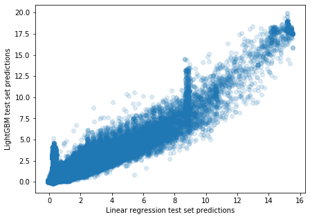

```python
plt.figure(figsize=(7,5))
plt.scatter(X_train_level2[:,0], X_train_level2[:,1], marker='o', alpha=0.15)
plt.xlabel('Linear regression test set predictions')
plt.ylabel('LightGBM test set predictions')
plt.show()
```

### Stacking

```python
y_train_level2 = Y_train2[dates_train.isin(periods)]
lr_stack = LinearRegression().fit(X_train_level2, y_train_level2)
```

```python
train_preds = lr_stack.predict(X_train_level2)
rmse_train = np.sqrt(mean_squared_error(y_train_level2, train_preds))

valid_preds = lr_stack.predict(X_valid_level2)
rmse_valid = np.sqrt(mean_squared_error(Y_valid2, valid_preds))

print('RMSE Train: %f' % rmse_train)
print('RMSE Test : %f' % rmse_valid)
```

```
RMSE Train: 0.819327
RMSE Test : 0.979985
```

## XGboost train

```python
import xgboost as xgb
```

```python
def xgtrain():
    regressor = xgb.XGBRegressor(n_estimators = 5000,
                                 learning_rate = 0.01,
                                 max_depth = 10,
                                 subsample = 0.5,
                                 colsample_bytree = 0.5)

    regressor_ = regressor.fit(X_train,
                               Y_train,
                               eval_metric = 'rmse',
                               eval_set = [(X_train,
                                            Y_train),
                                           (X_valid,
                                            Y_valid)
                                          ],
                               verbose=True,
                               early_stopping_rounds = 50,
                              )
    return regressor_
```

```python
%%time
model_xg = xgtrain()
```

[output not shown]

```python
#mean_squared_error
print(np.sqrt(mean_squared_error(Y_valid, model_xg.predict(X_valid))))
```

```
0.9217854
```

```
<BarContainer object of 43 artists>
```

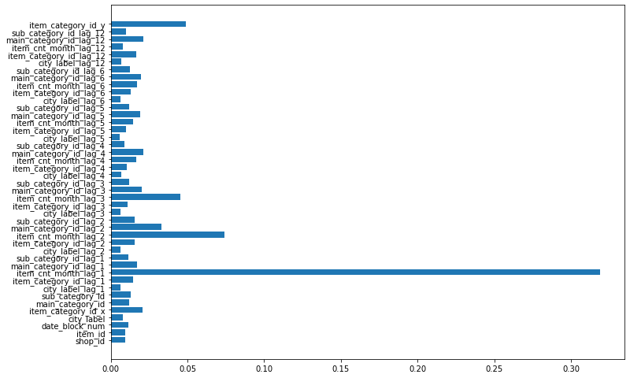

```python
from matplotlib import rcParams
rcParams['figure.figsize'] = 11.7,8.27

cols = all_data.drop('item_cnt_month', axis = 1).columns
plt.barh(cols, regressor_.feature_importances_)
plt.show()
```

### model file

```python
pkl_filename = "modelxg.pkl"
joblib.dump(model_xg, pkl_filename)
```

# Leaderboard test predictions

```python
#lgbm
predictions_lgbm = model_lgbm.predict(X_test)
smpsb_df['item_cnt_month'] = predictions_lgbm
smpsb_df.to_csv('sales_future_lgbm.csv', index=False)
```

```python
#lreg
predictions_lreg = model_linreg.predict(X_test)
smpsb_df['item_cnt_month'] = predictions_lreg
smpsb_df.to_csv('sales_future_lreg.csv', index=False)
```

```python
#xgboot best result
predictions_xg = model_xg.predict(X_test)
smpsb_df['item_cnt_month'] = predictions_xg
smpsb_df.to_csv('sales_future_xg.csv', index=False)
```